# Question

To evaluate the trigonometric functions by using the unit circle, it can be helpful to know the following:

| function | value |
| --- | --- |
| sine | $y$ |
| cosine | $x$ |
| tangent | $\frac{y}{x}$ |
| cosecant | $\frac{1}{y}$ |
| secant | $\frac{1}{x}$ |
| cotangent | $\frac{x}{y}$ |

The [unit circle](https://en.wikipedia.org/wiki/Unit_circle) below has a radius of length 1. The coordinates of special angles are shown.

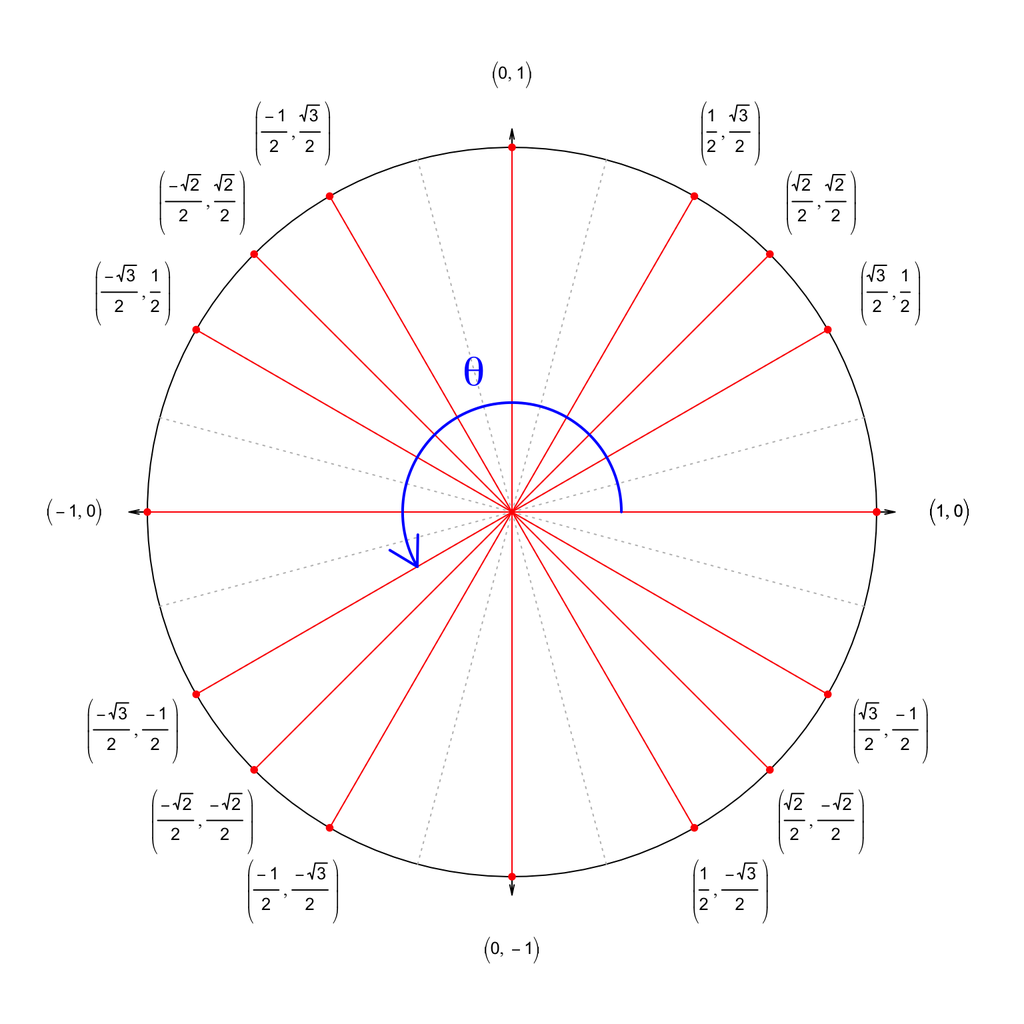

Determine $\csc\left(\theta\right)$. You might need to rationalize a denominator and/or simplify a fraction.

## Answerlist

- $-2$
- $-\sqrt{3}$
- $-\sqrt{2}$
- $\frac{-2\sqrt{3}}{3}$
- $-1$
- $\frac{-\sqrt{3}}{2}$
- $\frac{-\sqrt{2}}{2}$
- $\frac{-\sqrt{3}}{3}$
- $\frac{-1}{2}$
- $0$
- $\frac{1}{2}$
- $\frac{\sqrt{3}}{3}$
- $\frac{\sqrt{2}}{2}$
- $\frac{\sqrt{3}}{2}$
- $1$
- $\frac{2\sqrt{3}}{3}$
- $\sqrt{2}$
- $\sqrt{3}$
- $2$
- $\pm\infty$

# Solution

We know that $\csc\left(\theta\right)=\frac{1}{y}$. In this case, $\theta=\frac{7\pi}{6}$ and $x=\frac{-\sqrt{3}}{2}$ and $y=\frac{-1}{2}$. So

$$\csc\left(\frac{7\pi}{6}\right) =
\frac{1}{\frac{-1}{2}}$$

Simplify the fraction. You might need to rationalize a denominator.

$$\csc\left(\frac{7\pi}{6}\right)
= -2$$

It should be mentioned that the fact that $\theta=\frac{7\pi}{6}$ is not necessary to answer this question.

# Meta-information

extype: schoice exsolution: 10000000000000000000 exname: unit_circle_special